# Practical Machine Learning Assignment

KC

The aim of this project is to predict the type of activities done by a person based on data collected from various accelerometers placed on project participants. Details of the project can be found [here](http://groupware.les.inf.puc-rio.br/har).

We begin by loading the necessary library and files.

```r
library(caret)
training = read.csv("~/pml-training.csv")
testing = read.csv("~/pml-testing.csv")
```

The next task is to split the TRAINING data into 2 subgroups so we can cross validate the model before we apply it to the TESTING data.

```r
#Cross validation by spliting the TRAINING data into 80/20 (subtraining/control)
inTrain <- createDataPartition(y=training$classe, p=0.80, list=FALSE)
subtraining <- training[inTrain,]
control <- training[-inTrain,]
```

```r
#Create a list with all the Classe from subtraining
training_classe <- subtraining[,ncol(subtraining)]
#Visual inspection shows that column 1 to 7 are not needed
#Remove column 1-5 and 7 here
processed_training <- subtraining[,-c(1,2,3,4,5,7)]
#Create a list of TRUE/FALSE index for NA entries for all columns
training_NA_cols <- sapply(processed_training, function(x) { any(is.na(x)) })
#Remove columns with NA entries
processed_training <- processed_training[ , !training_NA_cols]
#Keep columns with only numbers
processed_training  <- processed_training[, sapply(processed_training, is.numeric)]

#Do the same to Control
control_classe <- control[,ncol(control)]
processed_control <- control[,-c(1,2,3,4,5,7)]
control_NA_cols <- sapply(processed_control, function(x) { any(is.na(x)) })
processed_control <- processed_control[ , !control_NA_cols]
processed_control  <- processed_control[, sapply(processed_control, is.numeric)]
processed_control <- cbind(processed_control, control_classe)
```

Despite having cleaned the data, the dimension of the data is still quite large. A principal component analysis (PCA) is used to transform the data and it is set such that it captures 95% of the variance. Once PCA is applied to the data, we combine the *classe* variables to the PCA-transformed data.

```r
#The dimension of the data is quite large (52 variables), applying PCA could help
#PCA set to capture 95% of the variance
pca <- preProcess(processed_training, method = "pca", thresh = 0.95)
#Apply PCA to the processed training to reduce dimensionality
pca_training <- predict(pca, processed_training)
dim(processed_training)
```

```
## [1] 15699    52
```

```r
dim(pca_training)
```

```
## [1] 15699    25
```

```r
#From 52 to 25 variables
#Combine the Training_Classe (from Clean and Tidy) back to the PCA_SubTraining
pca_subtraining <- cbind(pca_training, training_classe)
```

We managed to reduce the number of variables from 52 down to 25, which is a good thing as it will significantly reduce the runtime of the model training in the next stage.

Similarly, we will use PCA to transform the CONTROL data as well.

```r
#Apply the PCA earlier to the Control
pca_control <- predict(pca,control[,-ncol(control)])
```

```r
#Now to cross validate and see what the accuracy is
cross_val <- predict(model_rf, pca_control)
confusionMatrix(control$classe,cross_val)
```

```
## Confusion Matrix and Statistics
##
##           Reference
## Prediction    A    B    C    D    E
##          A 1100    3    3   10    0
##          B   24  722    6    2    5
##          C   48   15  608   10    3
##          D   20    5   33  583    2
##          E    5    5    5   11  695
##
## Overall Statistics
##
##                Accuracy : 0.9452
##                  95% CI : (0.9376, 0.9521)
##     No Information Rate : 0.3051
##     P-Value [Acc > NIR] : < 2.2e-16
##
##                   Kappa : 0.9305
##  Mcnemar's Test P-Value : 1.039e-14
##
## Statistics by Class:
##
##                      Class: A Class: B Class: C Class: D Class: E
## Sensitivity            0.9190   0.9627   0.9282   0.9464   0.9858
## Specificity            0.9941   0.9883   0.9767   0.9819   0.9919
## Pos Pred Value         0.9857   0.9513   0.8889   0.9067   0.9639
## Neg Pred Value         0.9654   0.9912   0.9855   0.9899   0.9969
## Prevalence             0.3051   0.1912   0.1670   0.1570   0.1797
## Detection Rate         0.2804   0.1840   0.1550   0.1486   0.1772
## Detection Prevalence   0.2845   0.1935   0.1744   0.1639   0.1838
## Balanced Accuracy      0.9565   0.9755   0.9525   0.9641   0.9889
```

We would expect the out-of-sample error rate to be less than 100% because the model wasn’t trained on the CONTROL data, and we would expect an overfit to the SUBTRAINING data due to the noise within. As shown above, the accuracy of the model is at 94.52%

Now we will clean and tidy the TESTING data and apply the same PCA transformation from above. The next step is to apply the trained random model to the TESTING data.

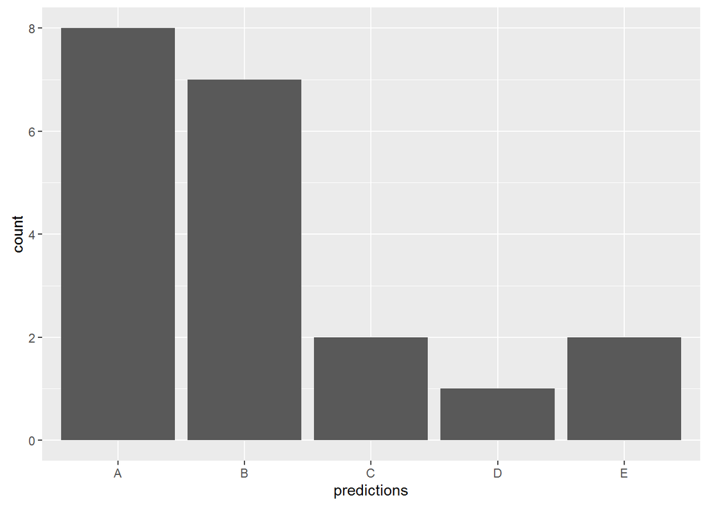

```r
#Process the testing data (same as Clean and Tidy)
# testing_classe <- testing[,ncol(testing)]
processed_testing <- testing[,-c(1,2,3,4,5,7)]
testing_NA_cols <- sapply(processed_testing, function(x) { any(is.na(x)) })
processed_testing <- processed_testing[ , !testing_NA_cols]
processed_testing  <- processed_testing[, sapply(processed_testing, is.numeric)]
# processed_testing <- cbind(processed_testing, testing_classe)

#Apply the PCA to the testing
#The last column in Process_Testing is a Problem ID, so it's not needed for prediction
pca_testing <- predict(pca,processed_testing[,-ncol(processed_testing)])

predictions <- predict(model_rf, pca_testing)
#summary(predictions)

#Display the predictions results in a barchart
ggplot(data.frame(predictions), aes(x=predictions)) + geom_bar()
```

From the above plot, we can see what the (total count) predictions are for the TESTING data. We would expect ~94% of these to be correct. (For the final quiz, we would expect our answers to have ~19 out of 20 correct.)

```r
#Predictions results in table format
#For the final Quiz. Not needed for the report
results <- data.frame(processed_testing$problem_id, predictions)
results
```

```
##    processed_testing.problem_id predictions
## 1                             1           B
## 2                             2           A
## 3                             3           A
## 4                             4           A
## 5                             5           A
## 6                             6           C
## 7                             7           D
## 8                             8           B
## 9                             9           A
## 10                           10           A
## 11                           11           B
## 12                           12           C
## 13                           13           B
## 14                           14           A
## 15                           15           E
## 16                           16           E
## 17                           17           A
## 18                           18           B
## 19                           19           B
## 20                           20           B
```

P.S. My result for the final quiz was 18/20 which is fairly close to the expected answer.